# Waterfowl - LTEM - EcoDomain Comparison

Published

2023-02-01

# 1 Summary of Waterfowl LTEM protocol

## 1.1 Basic protocol

As taken from the protocol document:

> “Establish observation points at enough sites to provide views of the entire survey area. …

> Choose a date after which migrants are mostly gone. Count on 3 separate occasions during a 2-3 week period and keep > highest count.”

The data collected under this protocol at each survey consists of the following variables:

- Species. The species of waterfowl counted.
- Sex. The sex of the species.
- Count. The number of birds of this species and sex. Choose a date after which migrants are mostly gone

## 1.2 Database structure

The relevant fields extracted from the database are:

- *SAMPLE_LABEL*. The label for the location where data was located.
- *Date*. The date the data was collected. The *Year* is extracted from this date.
- *Species*. What species were seen
- *Count*. Count of the number of birds of each species.

The longitude and latitude are used to find the EcoDomain of each study area.

# 2 Reading and checking the data

## 2.1 Extract all LTEM data

The database was queried for all observations from this protocol in the Province.

The following surveys and years of surveys were found.

```
Number of records in each study area x year combination
```

```
                      Year
STUDY_AREA_NAME_shrt   2007 2013 2014 2015 2016 2017 2018 2019 2020 2021
  Alice Lake Provincia    0    0    5    2    2    0    2    0    2    0
  Big Bar Lake Provinc    0    0    0    1    0    0    2    5    2    0
  Bowron Lake Provinci    0    0    0    1    0    0    0    0    0    0
  Brandywine Falls Pro    0    0    0    7    3    0    0    0    4    0
  Burges James Gadsden    0    0    0    2    2    0   15   29   54    0
  Call Lake Provincial    0    0    0   12    7    0    3    6    0    0
  Champion Lakes Provi    0    0    0    4    4    3    3    8    2    4
  Hai Lake Mount Herma    0    0    0   13   15   12   12   16   12    6
  Lac du Bois Provinci    0    2    1    1    0    0    0    0    3    0
  Mahoney Lake Ecologi    0    0    0   14   27   23   36   39   47    0
  Misty Lake Ecologica    3    0    0    5    6    7    4   10    0    0
  Naikoon Provincial P    0    0    0    2    0    1    0    0    0    0
  Nazko Lake Provincia    0    3    0    4    0    0    9    1    0    0
  Wells Gray Provincia    0    0    0    0    0    0    6    3    1    0
  White Lake Provincia    0    0    0    0    0    0    5    0    0    3
  Yellow Point Bog Eco    0   27   44  153   55  127    0   93    2  110
```

It is not necessary that every STUDY_AREA be measured in every year and the number of measurements at each STUDY_AREA can vary within years and across years.

If STUDY_AREA is only measured in one year, it does not provide any information on the trends and can be dropped. Similary, STUDY_AREAS with only 2 years of data, provide no information on the uncertainty; they can be retained or dropped.

STUDY_AREAs dropped for insuffient data are:

Study areas dropped because of insufficient years of data

[output not shown]

## 2.2 Ecodomain of each study area

The Ecodomain of each study area was obtained by looking up the mean latitude/longitude of observations for each STUDY_AREA in the Ecoprovices provided in the *bcmaps* package. In some cases, latitude/longitude is not provided as noted below:

```
Site missing long/lat data
```

```
  STUDY_AREA_NAME_shrt LONGITUDE_DD LATITUDE_DD
9 Mahoney Lake Ecologi           NA          NA
```

**How is it possible that long/lat is not know for some study area?**

The classification of each remaining STUDY_AREA into its EcoDomain is:

```
                      ECODOMAIN
STUDY_AREA_NAME_shrt   CoastMtn HumConHigh SemiAridHigh
  Alice Lake Provincia        1          0            0
  Big Bar Lake Provinc        0          1            0
  Brandywine Falls Pro        1          0            0
  Burges James Gadsden        0          1            0
  Call Lake Provincial        0          1            0
  Champion Lakes Provi        0          1            0
  Hai Lake Mount Herma        1          0            0
  Lac du Bois Provinci        0          0            1
  Misty Lake Ecologica        1          0            0
  Naikoon Provincial P        1          0            0
  Nazko Lake Provincia        0          1            0
  Wells Gray Provincia        0          1            0
  White Lake Provincia        0          1            0
  Yellow Point Bog Eco        1          0            0
```

```
# check if at least 2 eco domains at at least 4 study areas and at least 3 years x 2 ecodomains x 4 study area
```

## 2.3 Checking species code

There are many species of waterfowl.

**This table shows the total detections for each species.year combination in all STUDY_AREAs and EcoDomains**

```
               Year
SPECIES_CODE    2007 2013 2014 2015 2016 2017 2018 2019 2020 2021
  ANATIDAE         0    5    1    0    0    0    3   21    7    5
  ANSERIFORMES     0    0    0   15    8   14    2    0    0    0
  AVES             0    0    0    0    0    0    0    0    0   14
  AYTHYA          10    0    0    7   11    0    0    4    6    0
  B-ALFL           0    0    0    0    0    0    0    1    1    0
  B-AMCO           0    0    0    0    0    0    0    1    0    1
  B-AMRO           0    0    0    0    0    0    1    2    4    0
  B-AWPE           0    0    0    0    0    0    4    0    0    0
  B-BAEA           0    0    0    0    0    0    3    2    0    0
  B-BAGO           0    1    0    2    0    6    1    0    0    0
  B-BCCH           0    0    0    0    0    0    0    1    1    0
  B-BEKI           0    0    0    1    1    0    1    1    0    0
  B-BUFF           0    0   40   56   21    5   23   34    1    6
  B-BWTE           0    0    0    0    0    6    0    0    0    3
  B-CAGO           0   12    0   50    8    6   44   61    2    0
  B-CEWA           0    0    0    0    0    0    0    0    7    0
  B-CITE           0    0    0    0    0    4    0    0    0    0
  B-COGO           0    0    0    1   11    0    3   12    8    0
  B-COLO           0    0    0    1    0    0    5    4    5    1
  B-COME           0    0    4    8    3    1    1    8    1    5
  B-CORA           0    0    0    0    0    0    0    2    3    0
  B-EAGR           0    0    0    0    0    7    0    0    0    0
  B-EAKI           0    0    0    0    0    0    0    7    4    0
  B-GBHE           0    0    2    2    1    0    0    3    0    1
  B-GRSC           0    0    2    0    6    1    0    0    0    0
  B-GWTE           0    0    0   21    7    4    0    0    0    2
  B-HOME           0   27   34   92   51   84    0   89    0   88
  B-KILL           0    0    0    0    0    0    0    1    0    0
  B-LESC           0   14    0   83   10   41    2    2    0    7
  B-MALL           0   36   36   72   18  108   17   59    7   66
  B-NOPI           0    0    0    0    0    1    0    6    0    0
  B-OCWA           0    0    0    0    0    0    0    1    0    0
  B-OSFL           0    0    0    0    0    0    0    1    2    0
  B-OSPR           0    0    0    0    0    0    1    0    3    0
  B-PBGR           0    0    0    2    0   12    0    2    0    8
  B-PIGR           0    0    0    0    0    0    0    1    0    0
  B-RBME           0    0    0    0    0    0    0    5    0    0
  B-RNDU           0    0    2   97   18   44    0   52    0   89
  B-RNGR           0    0    0    2    9    0    0    0    0    0
  B-SACR           0    2    0    1    0    0    1    0    0    0
  B-TRSW           0    0    0    0    0    0    0   13   42    0
  B-TRUS           0    0    3    5    0    6    0    0    0    8
  B-TUVU           0    0    0    0    0    0    0    0    3    0
  B-VATH           0    0    0    0    0    0    0    1    1    0
  B-WISN           0    0    0    0    2    0    2    0    0    0
  B-WIWA           0    0    0    0    0    0    0    1    0    0
  B-WIWR           0    0    0    0    0    0    0    4    0    0
  B-WODU           0    0    0    8    2    4    0    4    1    0
  B-YEWA           0    0    0    0    0    0    0    1    6    0
  BOMBYCILLIDAE    0    0    0    0    0    0    1    0    0    0
  BUCEPHALA        0    0    1    1    0    0    0    1    0    0
  CHARADRIIDAE     0    0    0    0    0    0    1    0    0    0
  MERGUS           0    0    0    0    0    0    0    3    0    0
  NULL             0    0    0    0    0    0    0    0    0    0
  PASSERIFORMES    0    0    0    0    0    0    6    0    0    0
  PODICIPEDIDAE    0    0    0    0    0    0    0    2    0    0
```

```
*** WARNING *** More than one species name found - OK if some are NULL
```

# 3 Multi-Site Analysis

We will now compare the trends in the EcoDomains.

This design has multiple STUDY_AREA_NAMES that are repeatedly measured over time. Please refer to the Fitting Trends with Complex Study Designs document in the CommonFile directory for information on fitting trends with complex study designs.

All analyses were done using the R (R Core Team, 2023) analysis system. All plots are also saved as separate *png files for inclusion into other reports.

## 3.1 Maximum counts

The data is first summarized to the date level by summing the count over the different species for each date-sample station combination. This reduces the data to one measurement per date per site/year.

The first few records are:

```
  STUDY_AREA_NAME_shrt ECODOMAIN Year       Date    SAMPLE_LABEL total.count                               SA.SAMPLE_LABEL
1 Alice Lake Provincia  CoastMtn 2014 2014-04-09 Site 1 + Site 2           9 Alice Lake Provincial Park....Site 1 + Site 2
2 Alice Lake Provincia  CoastMtn 2014 2014-04-11 Site 1 + Site 2           7 Alice Lake Provincial Park....Site 1 + Site 2
3 Alice Lake Provincia  CoastMtn 2015 2015-04-10          Site 1           0          Alice Lake Provincial Park....Site 1
4 Alice Lake Provincia  CoastMtn 2015 2015-04-10          Site 2           0          Alice Lake Provincial Park....Site 2
5 Alice Lake Provincia  CoastMtn 2016 2016-04-19          Site 1           2          Alice Lake Provincial Park....Site 1
6 Alice Lake Provincia  CoastMtn 2016 2016-04-19          Site 2           0          Alice Lake Provincial Park....Site 2
```

### 3.1.1 Preliminary plot

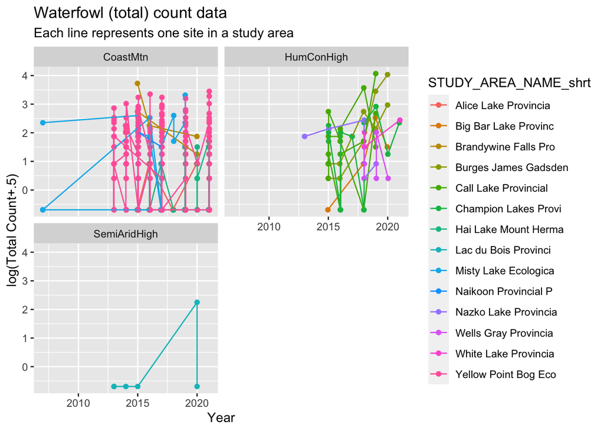

Figure 1: Summary plot of the data. The data is analyzed on the logarithmic scale.

Each line represents a particular station within a STUDY_AREA.

### 3.1.2 Obtain maximum count in N/D/J/F

Next the maximum count in each month in each station is found. The maximum counts are:

```
    STUDY_AREA_NAME_shrt    ECODOMAIN      SAMPLE_LABEL Year Month max.count
1   Alice Lake Provincia     CoastMtn            Site 1 2015     4         0
2   Alice Lake Provincia     CoastMtn            Site 1 2016     4         2
3   Alice Lake Provincia     CoastMtn            Site 1 2018     5         0
4   Alice Lake Provincia     CoastMtn            Site 1 2020     4         2
5   Alice Lake Provincia     CoastMtn   Site 1 + Site 2 2014     4         9
6   Alice Lake Provincia     CoastMtn            Site 2 2015     4         0
7   Alice Lake Provincia     CoastMtn            Site 2 2016     4         0
8   Alice Lake Provincia     CoastMtn            Site 2 2018     5         0
9   Big Bar Lake Provinc   HumConHigh        Otter Lake 2015     6         0
10  Big Bar Lake Provinc   HumConHigh        Otter Lake 2018     6         2
11  Big Bar Lake Provinc   HumConHigh        Otter Lake 2019     7        12
12  Big Bar Lake Provinc   HumConHigh        Otter Lake 2020     6         4
13  Brandywine Falls Pro     CoastMtn         Station 1 2015     5        41
14  Brandywine Falls Pro     CoastMtn         Station 1 2016     4         9
```

[output cut: 250 more lines]

When the maximum counts are restricted to November, December, January, and February, the data are now:

```
    STUDY_AREA_NAME_shrt ECODOMAIN SAMPLE_LABEL Year Month max.count
131 Misty Lake Ecologica  CoastMtn  Boat Launch 2007    12        10
134 Misty Lake Ecologica  CoastMtn  Boat Launch 2015    11         7
139 Misty Lake Ecologica  CoastMtn  Boat Launch 2019     1        10
141 Misty Lake Ecologica  CoastMtn          ML2 2007    12         0
144 Misty Lake Ecologica  CoastMtn          ML3 2007    12         0
162 Yellow Point Bog Eco  CoastMtn  Obs Pt East 2013    11         6
163 Yellow Point Bog Eco  CoastMtn  Obs Pt East 2014     1        12
164 Yellow Point Bog Eco  CoastMtn  Obs Pt East 2014     2         0
165 Yellow Point Bog Eco  CoastMtn  Obs Pt East 2014    11         2
166 Yellow Point Bog Eco  CoastMtn  Obs Pt East 2014    12         9
167 Yellow Point Bog Eco  CoastMtn  Obs Pt East 2015     1         6
168 Yellow Point Bog Eco  CoastMtn  Obs Pt East 2015     2         6
173 Yellow Point Bog Eco  CoastMtn  Obs Pt East 2015    11         5
174 Yellow Point Bog Eco  CoastMtn  Obs Pt East 2015    12        17
```

[output cut: 33 more lines]

Many STUDY_AREA_NAMEs were NOT measured in N/D/J/F, so the remainining data are:

```
                      Year
STUDY_AREA_NAME_shrt   2007 2013 2014 2015 2016 2017 2019 2021
  Misty Lake Ecologica    3    0    0    1    0    0    1    0
  Yellow Point Bog Eco    0    3    8    6    3    6    8    8
```

```
                      ECODOMAIN
STUDY_AREA_NAME_shrt   CoastMtn
  Misty Lake Ecologica        5
  Yellow Point Bog Eco       42
```

**Does this seem right that most study areas have NO overwintering waterfowl?** **Does this seem right that we now only have 1 ECODOMAIN**. No analysis is possible to compare trends across ECODOMAINS.

```
*** ERROR *** Only one ecodomain left. No analysis comparing trends across ECODOMAINS is possible
```